# dane_travel_insurance

## Opis projektu

W branży ubezpieczeniowej kluczowym aspektem działalności jest skuteczne zarządzanie ryzykiem i podejmowanie trafnych decyzji dotyczących rozpatrywania roszczeń klientów. Ubezpieczyciele, analizując duże zbiory danych historycznych, dążą do identyfikacji wzorców pozwalających przewidzieć, czy zgłoszone roszczenie powinno zostać zaakceptowane, czy odrzucone.

Celem projektu było zbadanie skuteczności sztucznych sieci neuronowych w klasyfikacji roszczeń z ubezpieczenia turystycznego, gdzie zmienna claim określa decyzję o akceptacji (1) lub odrzuceniu (0) zgłoszenia.

Ocenie poddano zarówno autorskie implementacje sieci perceptronowych, jak i gotowe modele MLP z biblioteki scikit-learn. Głównym celem było określenie, jak różne architektury i konfiguracje sieci wpływają na skuteczność klasyfikacji roszczeń ubezpieczeniowych.

## Literatura

*[Application of Deep Learning and Neural Network to Speeding Ticket and Insurance Claim Count Data](https://www.mdpi.com/2075-1680/11/6/280)*

Badanie dotyczy porównania różnych modeli regresji zliczeniowej w prognozowaniu liczby mandatów za przekroczenie prędkości oraz roszczeń ubezpieczeniowych. Szczególny nacisk położono na analizę modeli w warunkach wysokiej współliniowości i nienormalności danych wejściowych. Zastosowano zarówno dane rzeczywiste (z Singapuru), jak i dane symulowane (m.in. z użyciem kopuli i rozkładów asymetrycznych).

Porównano skuteczność modeli takich jak: sieci neuronowe (MLP), głęboka sieć DLk (stworzona przez autorów), gradient boosting (GBM), oraz modele regresji Poissona czy ujemno-dwumianowej z wykorzystaniem analizy głównych składowych (PCA). Sieci neuronowe zbudowano przy użyciu Keras i TensorFlow.

Autorzy wykazali, że modele deep learning są wysoce skuteczne w analizie złożonych danych zliczeniowych, szczególnie w obecności nieliniowości, współliniowości i asymetrii danych. W wielu przypadkach sieci neuronowe przewyższyły klasyczne modele regresji w zakresie dokładności prognoz.

Kim, J.-M., Kim, J., & Ha, I. D. (2022). Application of Deep Learning and Neural Network to Speeding Ticket and Insurance Claim Count Data. Axioms, 11(6), 280. https://doi.org/10.3390/axioms11060280

*[Analysis of Deep Neural Networks for Automobile Insurance Claim Prediction](https://link.springer.com/chapter/10.1007/978-981-32-9563-6_12)*

Celem badania było zastosowanie głębokich sieci neuronowych (DNN) do predykcji roszczeń z ubezpieczeń komunikacyjnych. Problem potraktowano jako klasyfikację binarną: model przewidywał, czy klient złoży roszczenie (0/1). Wykorzystano dane z konkursu Kaggle, zawierające około 600 tys. obserwacji – dane były silnie niezbalansowane.

Zaproponowany model oparto na sieci neuronowej z trzema warstwami ukrytymi, warstwą embeddingu dla zmiennych kategorycznych oraz mechanizmem dropout zapobiegającym nadmiernemu dopasowaniu. Użyto metryki znormalizowanego współczynnika Giniego. Przeprowadzono strojenie hiperparametrów.

DNN osiągnął lepsze wyniki niż klasyczna sieć neuronowa oraz modele takie jak Random Forest i AdaBoost, jednak minimalnie ustępował modelowi XGBoost. Wyniki badania potwierdzają skuteczność głębokich sieci neuronowych w analizie złożonych danych ubezpieczeniowych.

Saputro, A. R., Murfi, H., & Nurrohmah, S. (2019, July). Analysis of deep neural networks for automobile insurance claim prediction. In International Conference on Data Mining and Big Data (pp. 114-123). Singapore: Springer Singapore.

*Optimizing Travel Insurance Purchase Detection using Predictive Models*

Celem badania było stworzenie modelu predykcyjnego przewidującego decyzję klienta o zakupie ubezpieczenia podróżnego. Wykorzystano publicznie dostępne dane z Kaggle, zawierające cechy takie jak wiek, płeć, typ agencji, kraj docelowy, długość podróży, kanał dystrybucji i rodzaj produktu.

Dane poddano preprocessingowi (standaryzacja, one-hot encoding) i podzielono w proporcji 70:30. Przetestowano kilka modeli klasyfikacyjnych: Random Forest, Decision Tree, KNN, regresję logistyczną, Naive Bayes oraz sieć neuronową typu MLP (z dwiema warstwami ukrytymi).

Najwyższą dokładność (96%) osiągnął model Random Forest, przewyższając pozostałe algorytmy. MLP osiągnął niższą skuteczność, lecz uznany został za konkurencyjny model. Wskazano, że najbardziej wpływowe cechy to długość podróży, kanał dystrybucji, typ agencji i wiek. Autorzy podkreślają, że modele uczenia maszynowego pozwalają skutecznie identyfikować klientów o wysokim prawdopodobieństwie zakupu, co wspiera efektywne targetowanie ofert ubezpieczeniowych.

Borketey, B., Aboagye, E. F., & Danquah, K. (2024). Optimizing travel insurance purchase detection using predictive models. Int. J. Autom. Artif. Intell. Mach. Learn, 4(2), 173-207.

## Biblioteki

```python
import pandas as pd
import seaborn as sns
from scipy import stats
import matplotlib.pyplot as plt
from sklearn.model_selection import train_test_split
from sklearn.preprocessing import StandardScaler, OneHotEncoder
from sklearn.linear_model import LogisticRegression
from sklearn.metrics import accuracy_score, recall_score, precision_score, confusion_matrix
from sklearn.cluster import DBSCAN
from sklearn.compose import make_column_transformer
from sklearn.pipeline import make_pipeline
from tabulate import tabulate
import warnings
import numpy as np
from perceptron import MLPExperiment
import json
from matplotlib.gridspec import GridSpec
```

## Przygotowanie danych

```python
data = pd.read_csv("dane/travel_insurance.csv", sep=",", decimal=",")
```

```python
data.head(10)
```

|  | ID | Age | Agency | Agency Type | Commision (in value) | Destination | Distribution Channel | Duration | Gender | Net Sales | Product Name | Claim |
| --- | --- | --- | --- | --- | --- | --- | --- | --- | --- | --- | --- | --- |
| 0 | 45341 | 28 | C2B | Airlines | 28.13 | SINGAPORE | Online | 34 | F | 112.5 | Silver Plan | 1 |
| 1 | 12958 | 37 | JZI | Airlines | 12.95 | PHILIPPINES | Online | 53 | F | 37.0 | Basic Plan | 0 |
| 2 | 18233 | 27 | EPX | Travel Agency | 0.0 | UNITED STATES | Online | 28 | NaN | 13.0 | Cancellation Plan | 0 |
| 3 | 31742 | 36 | EPX | Travel Agency | 0.0 | SAUDI ARABIA | Online | 1 | NaN | 34.0 | Cancellation Plan | 0 |
| 4 | 14381 | 26 | CWT | Travel Agency | 23.76 | THAILAND | Online | 33 | NaN | 39.6 | Rental Vehicle Excess Insurance | 0 |
| 5 | 9279 | 39 | CWT | Travel Agency | 59.4 | AUSTRALIA | Online | 78 | NaN | 99.0 | Rental Vehicle Excess Insurance | 0 |
| 6 | 6217 | 34 | CWT | Travel Agency | 23.76 | AUSTRALIA | Online | 27 | NaN | 0.0 | Rental Vehicle Excess Insurance | 0 |
| 7 | 52027 | 45 | JZI | Airlines | 9.1 | HONG KONG | Online | 10 | M | 26.0 | Basic Plan | 0 |
| 8 | 24167 | 32 | C2B | Airlines | 63.21 | SINGAPORE | Online | 368 | M | 252.85 | Annual Silver Plan | 1 |
| 9 | 19885 | 59 | C2B | Airlines | 63.21 | SINGAPORE | Online | 377 | F | 252.85 | Annual Silver Plan | 0 |

Zestaw danych zawiera informacje o 62288 klientach. W zbiorze znajdują się zmienne:

- **Claim**: Status roszczenia (czy zostało zaakceptowane: 1-tak, 0-nie).
- **Agency**: Nazwa agencji ubezpieczeniowej (kod agencji).
- **Agency.Type**: Typ agencji: Airlines lub Travel Agency.
- **Distribution**.Channel: Kanał dystrybucji używany przez agencję ubezpieczeniową.
- **Product.Name**: Nazwa produktu ubezpieczeniowego.
- **Duration**: Czas trwania ubezpieczenia.
- **Destination**: Miejsce docelowe podróży.
- **Net.Sales**: Kwota sprzedaży polis ubezpieczeniowych (czyli po uwzględnieniu kosztów).
- **Commission**: Wysokość prowizji uzyskanej przez agencję ubezpieczeniową.
- **Gender**: Płeć osoby ubezpieczonej.
- **Age**: Wiek osoby ubezpieczonej.

### Statystyki opisowe

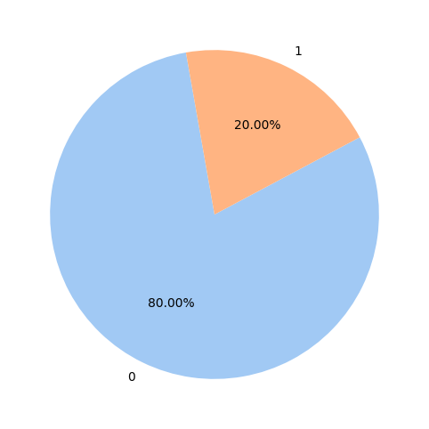

```python
x=data.Claim.value_counts()
plt.figure(figsize=(12, 6))
plt.pie(x, labels=x.index, autopct='%1.2f%%', startangle=100, colors=sns.color_palette('pastel'))
plt.show()
```

W zbiorze danych obserwuje się znaczną nierównowagę klas – około 80% roszczeń zostało odrzuconych (0), a jedynie 20% zaakceptowanych (1).

```python
data.info()
```

```
<class 'pandas.core.frame.DataFrame'>
RangeIndex: 62288 entries, 0 to 62287
Data columns (total 12 columns):
 #   Column                Non-Null Count  Dtype
---  ------                --------------  -----
 0   ID                    62288 non-null  int64
 1   Age                   62288 non-null  int64
 2   Agency                62288 non-null  object
 3   Agency Type           62288 non-null  object
 4   Commision (in value)  62288 non-null  object
 5   Destination           62288 non-null  object
 6   Distribution Channel  62288 non-null  object
 7   Duration              62288 non-null  int64
 8   Gender                22713 non-null  object
 9   Net Sales             62288 non-null  object
 10  Product Name          62288 non-null  object
 11  Claim                 62288 non-null  int64
dtypes: int64(4), object(8)
memory usage: 5.7+ MB
```

Spośród 11 zmiennych obecnych w zbiorze danych, 3 mają pierwotnie charakter numeryczny, podczas gdy pozostałe 8 to zmienne tekstowe. Jednak zmienne **Net Sales** oraz **Commission (in value)**, mimo że były zapisane jako tekstowe, zawierają dane numeryczne. W związku z tym zostały przekonwertowane na typ numeryczny, aby umożliwić ich poprawną analizę.

```python
data['Net Sales']= pd.to_numeric(data['Net Sales'])
data['Commision (in value)']= pd.to_numeric(data['Commision (in value)'])
```

W kolejnym kroku przeanalizowano brakujące dane. Spośród wszystkich zmiennych braki występują wyłącznie w zmiennej **Gender**, gdzie stanowią około 64% wszystkich wartości. Z tego powodu zdecydowano się na usunięcie tej zmiennej.

```python
missing_data = pd.DataFrame({'Missing Count': data.isnull().sum(), 'Missing Percentage': 100 * data.isnull().sum() / len(data)}).sort_values('Missing Count', ascending=False)
print(tabulate(missing_data, headers=['Zmienna', 'Braki danych', '%'], tablefmt='pretty'))
```

```
+----------------------+--------------+-------------------+
|       Zmienna        | Braki danych |         %         |
+----------------------+--------------+-------------------+
|        Gender        |   39575.0    | 63.53551245825841 |
|          ID          |     0.0      |        0.0        |
|        Agency        |     0.0      |        0.0        |
|         Age          |     0.0      |        0.0        |
|     Agency Type      |     0.0      |        0.0        |
| Commision (in value) |     0.0      |        0.0        |
| Distribution Channel |     0.0      |        0.0        |
|     Destination      |     0.0      |        0.0        |
|       Duration       |     0.0      |        0.0        |
|      Net Sales       |     0.0      |        0.0        |
|     Product Name     |     0.0      |        0.0        |
|        Claim         |     0.0      |        0.0        |
+----------------------+--------------+-------------------+
```

Za pomocą funkcji **describe()** z biblioteki pandas sprawdzono podstawowe statystyki opisujące dane.

```python
data.describe()
```

|  | ID | Age | Commision (in value) | Duration | Net Sales | Claim |
| --- | --- | --- | --- | --- | --- | --- |
| count | 62288.000000 | 62288.000000 | 62288.000000 | 62288.000000 | 62288.000000 | 62288.000000 |
| mean | 32844.953458 | 39.666324 | 12.829703 | 60.958804 | 50.717064 | 0.200006 |
| std | 18065.417216 | 14.014652 | 23.498745 | 114.325330 | 63.166715 | 0.400008 |
| min | 0.000000 | 0.000000 | 0.000000 | -2.000000 | -389.000000 | 0.000000 |
| 25% | 17579.000000 | 33.000000 | 0.000000 | 10.000000 | 20.000000 | 0.000000 |
| 50% | 33446.500000 | 36.000000 | 1.880000 | 25.000000 | 29.700000 | 0.000000 |
| 75% | 48532.250000 | 43.000000 | 14.440000 | 59.000000 | 58.000000 | 0.000000 |
| max | 63323.000000 | 118.000000 | 262.760000 | 4881.000000 | 682.000000 | 1.000000 |

1. **Wiek (Age)**:
- **Minimum**: 0 – wartość akceptowalna.
- **Maksimum**: 118 – wartość znacząco przekraczająca typowy wiek podróżnych.

Według informacji od firm ubezpieczeniowych, większość z nich nie oferuje polis osobom powyżej 85 roku życia, choć nieliczne mogą obsługiwać klientów do 99 lat.

2. **Prowizja (Commission)**:

Dane dotyczące prowizji nie wymagają dodatkowych poprawek.

3. **Czas trwania (Duration)**:
- **Minimum**: -2 – wartość ujemna jest niedopuszczalna i wymaga korekty.
- **Maksimum**: 4881 – wartość ta jest nierealistyczna dla okresu ochrony ubezpieczeniowej.

Zgodnie z wytycznymi firm ubezpieczeniowych istnieje możliwość zakupu rocznego planu, co stanowi okres ochrony do 365 dni. Dodatkowo, jeśli uwzględnimy możliwość wcześniejszego zakupu biletu na rok w przód, maksymalny czas trwania ubezpieczenia mógłby wynosić 731 dni (365 dni + 366 dni w przypadku roku przestępnego).

4. **Sprzedaż netto (Net Sales)**:

Występują wartości ujemne, co wymaga analizy, czy takie przypadki są uzasadnione.

Sprzedaż netto obliczana jest według wzoru:

$$ \text{Net Sales} = \text{Wartość sprzedaży ubezpieczenia} - \frac{\text{Koszty poniesione}}{\text{Wypłacona kwota roszczenia}} $$

Ujemne wartości mogą wynikać z wypłaconych roszczeń, gdzie koszty przewyższają przychody. Dodatkowo mogą one pojawiać się w przypadkach, gdy roszczenie zostało zgłoszone, ale odrzucone – w takich sytuacjach koszty związane z dochodzeniem mogły przewyższyć wartość polisy.

W kolejnym kroku zaimplementowano funkcję `data_pre_processing()`, która przeprowadza przetwarzanie danych. Funkcja usuwa kolumny **Gender**, **ID** oraz **Destination**, ponieważ uznano je za nieistotne dla dalszej analizy. Dodatkowo funkcja zajmuje się poprawą jakości danych poprzez zamianę błędnych wartości w kolumnach **Age** oraz **Duration**, co pozwala na zachowanie spójności i wiarygodności danych wejściowych.

```python
def data_pre_processing(df):
    df.drop('Gender',axis =1, inplace=True)
    df.drop('ID',axis =1, inplace=True)
    df.drop('Destination',axis =1, inplace=True)

    df['Duration'][df['Duration'] < 0] = df['Duration'].median()
    df['Duration'][df['Duration'] > 731] = 731
    df['Age'][df['Age'] > 99] = 99

data_pre_processing(data)
```

```python
data.describe()
```

|  | Age | Commision (in value) | Duration | Net Sales | Claim |
| --- | --- | --- | --- | --- | --- |
| count | 62288.000000 | 62288.000000 | 62288.000000 | 62288.000000 | 62288.000000 |
| mean | 39.390878 | 12.829703 | 60.182748 | 50.717064 | 0.200006 |
| std | 12.586263 | 23.498745 | 94.270276 | 63.166715 | 0.400008 |
| min | 0.000000 | 0.000000 | 0.000000 | -389.000000 | 0.000000 |
| 25% | 33.000000 | 0.000000 | 10.000000 | 20.000000 | 0.000000 |
| 50% | 36.000000 | 1.880000 | 25.000000 | 29.700000 | 0.000000 |
| 75% | 43.000000 | 14.440000 | 59.000000 | 58.000000 | 0.000000 |
| max | 99.000000 | 262.760000 | 731.000000 | 682.000000 | 1.000000 |

Do przygotowania danych wykorzystano pomocnicze funkcje:

- `change_categorical_data` - **zmienia wartości kolumn kategorycznych na wartości numeryczne**. Dla każdej kolumny o typie object tworzy nowe kolumny reprezentujące unikalne wartości tej kolumny, przypisując im wartości binarne. Opcjonalnie usuwa pierwszą kategorię (drop_first=True), aby uniknąć współliniowości, a na końcu usuwa oryginalne kolumny kategoryczne z ramki danych.
- `remove_outliers_dbscan` - usuwa wartości odstające z danych przy użyciu algorytmu DBSCAN. Polega on na grupowaniu danych na podstawie gęstości punktów w przestrzeni oraz wykrywaniu wartości odstających (szumu). Punkty, które znajdują się blisko siebie i mają wystarczająco wielu sąsiadów, są grupowane w klastrach. Punkty, które nie należą do żadnego klastra, są traktowane jako wartości odstające. Algorytm ten przyjmuje jako argumenty:
  - `eps` - odległość, która określa, jak daleko mogą być dwa punkty, aby nadal być uznawane za sąsiadów. (Domyślnie 0.5)
  - `min_samples` - minimalna liczba punktów w grupie, aby utworzyć klaster. (Domyślnie 5)

```python
def change_categorical_data(df, drop=True):
    data=df.copy()
    for col in data.columns:
        if data[col].dtype == 'object':
            column_dummies = pd.get_dummies(data[col], dtype=int, drop_first=drop)
            column_dummies.columns = [f'{col}_{label}' for label in column_dummies.columns]
            data = pd.concat([data, column_dummies], axis=1)
            data.drop(col, axis=1, inplace=True)
    return data


def remove_outliers_dbscan(data):
    print("Przed usunięciem outlierów:", data.shape)

    # Change categorical data to numerical
    df_numeric = change_categorical_data(data, drop=True)

    scaler = StandardScaler()
    scaled_features = scaler.fit_transform(df_numeric)

    dbscan = DBSCAN(eps=0.5, min_samples=5)
    clusters = dbscan.fit_predict(scaled_features)

    df_numeric['cluster'] = clusters
    df_numeric = df_numeric[df_numeric['cluster'] != -1].drop('cluster', axis=1)

    # Convert back to original dataframe with categorical columns
    df_cleaned = data[data.index.isin(df_numeric.index)]

    print("Po usunięciu outlierów:")
    print(df_cleaned.shape)
    return df_cleaned

# Usuwanie outlierów
data = remove_outliers_dbscan(data)
```

```
Przed usunięciem outlierów: (62288, 9)
Po usunięciu outlierów:
(61358, 9)
```

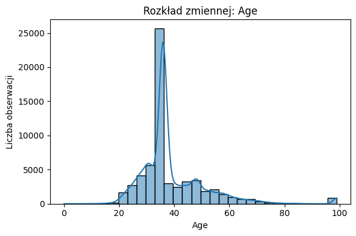

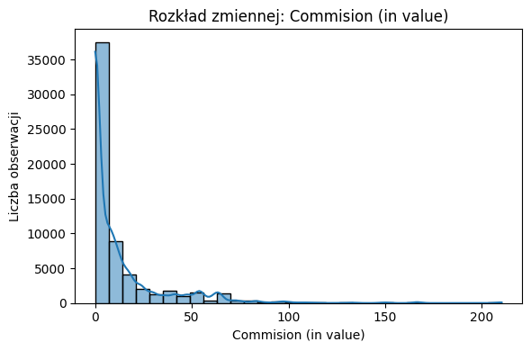

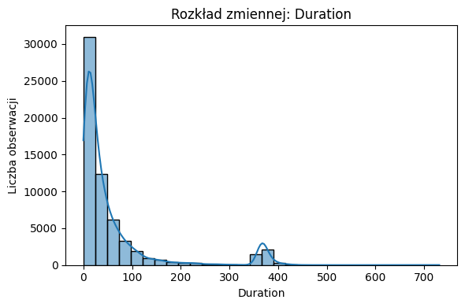

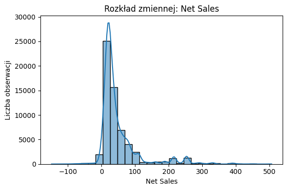

```python
def plot_distributions(data, bins=30):
    numeric_cols = data.select_dtypes(include=['int64', 'float64']).columns
    numeric_cols = numeric_cols.drop('Claim', errors='ignore')

    for col in numeric_cols:
        plt.figure(figsize=(6, 4))
        sns.histplot(data[col], bins=bins, kde=True)
        plt.title(f"Rozkład zmiennej: {col}")
        plt.xlabel(col)
        plt.ylabel("Liczba obserwacji")
        plt.tight_layout()
        plt.show()

plot_distributions(data)
```

**Age** - Rozkład wieku klientów jest asymetryczny prawostronnie - dominują osoby w wieku około 35–40 lat, natomiast liczba starszych klientów stopniowo maleje. Pojedyncze obserwacje powyżej 80 roku życia stanowią wyjątki.

**Commision** - Rozkład prowizji jest silnie skośny prawostronnie – większość wartości prowizji jest niska (bliska zera), a tylko nieliczne obserwacje osiągają wysokie wartości. Wskazuje to na duże zróżnicowanie w strukturze wynagrodzeń agencji.

**Duration** - Czas trwania ubezpieczenia ma silnie skośny prawostronnie rozkład – większość ubezpieczeń trwa krócej niż 50 dni, natomiast nieliczne obserwacje przekraczają 300 dni (najprawdopodobniej caloroczne ubezpieczenia).

**Net Sales** - Zmienne charakteryzuje asymetryczny rozkład prawostronny – większość wartości skupia się w pobliżu zera, z pojedynczymi obserwacjami osiągającymi bardzo wysokie wyniki. Nieliczne wartości ujemne mogą wynikać z korekt lub zwrotów polis.

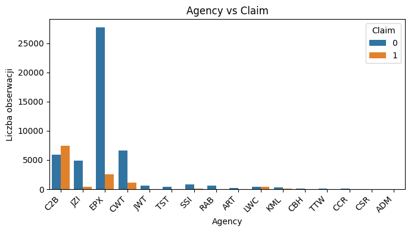

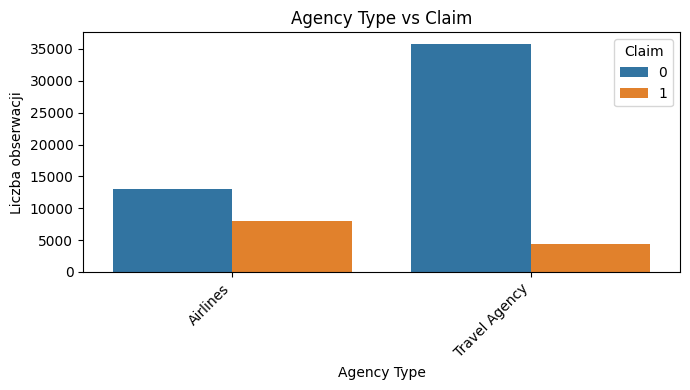

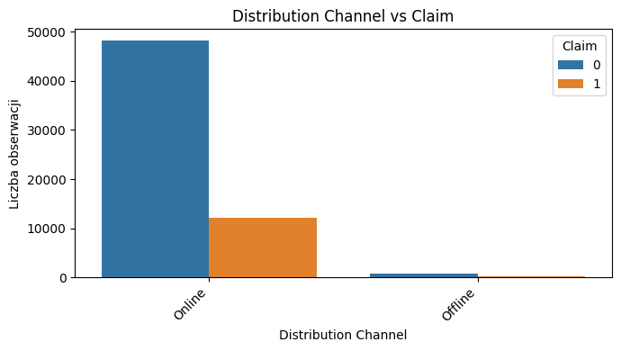

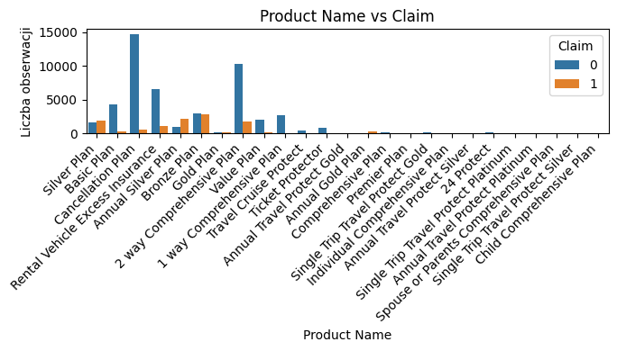

```python
def plot_relationships(data, target='Claim', top_n=10):
    categorical_cols = data.select_dtypes(include='object').columns.tolist()
    if target in categorical_cols:
        categorical_cols.remove(target)

    for col in categorical_cols:
        if col == 'Product.Name':
            top_values = data[col].value_counts().nlargest(top_n).index
            filtered_data = data[data[col].isin(top_values)]
        else:
            filtered_data = data

        plt.figure(figsize=(7, 4))
        sns.countplot(x=col, hue=target, data=filtered_data)
        plt.title(f"{col} vs {target}")
        plt.ylabel("Liczba obserwacji")
        plt.xticks(rotation=45, ha='right')
        plt.tight_layout()
        plt.show()

plot_relationships(data, target='Claim', top_n=10)
```

**Agency Type vs Claim** - Większość roszczeń pochodzi z biur podróży (Travel Agency), jednak dominują wśród nich przypadki odrzucone (Claim = 0). Agencje typu Airlines generują mniej zgłoszeń, ale w ich przypadku udział zaakceptowanych roszczeń jest relatywnie wyższy, co może wskazywać na lepszą jakość obsługi lub inną strukturę oferowanych polis.

**Distribution channel vs Claim** - Zdecydowana większość polis została sprzedana online, przy czym w tym kanale dominuje liczba odrzuconych roszczeń (Claim = 0). Sprzedaż offline stanowi marginalny udział w danych oraz i tak wyższe jest odrzucenie roszczenia.

**Product Name vs Claim** - Najwięcej zgłoszeń roszczeń dotyczy polis typu "Cancellation Plan" i "2 way Comprehensive Plan", przy czym w obu przypadkach dominuje liczba odrzuconych roszczeń (Claim = 0). Stosunkowo więcej zaakceptowanych roszczeń (Claim = 1) obserwuje się w produkcie "Bronze Plan", co może sugerować, że rodzaj produktu ubezpieczeniowego ma wpływ na prawdopodobieństwo akceptacji roszczenia.

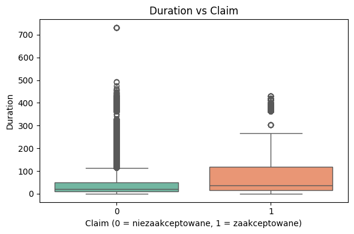

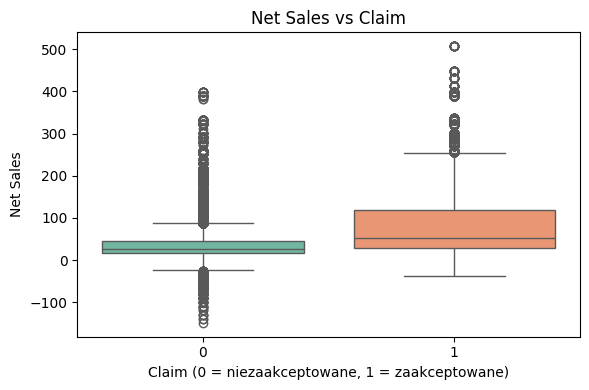

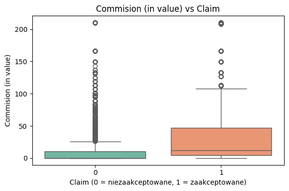

```python
cols = ['Duration', 'Net Sales', 'Commision (in value)']

for col in cols:
    plt.figure(figsize=(6, 4))
    sns.boxplot(x='Claim', y=col, data=data, palette='Set2')
    plt.title(f"{col} vs Claim")
    plt.xlabel("Claim (0 = niezaakceptowane, 1 = zaakceptowane)")
    plt.ylabel(col)
    plt.tight_layout()
    plt.show()
```

**Duration vs Claim** - Zaakceptowane roszczenia (Claim = 1) dotyczą zazwyczaj polis o dłuższym okresie ubezpieczenia w porównaniu do tych odrzuconych (Claim = 0). Mediana czasu trwania dla zaakceptowanych roszczeń jest wyraźnie wyższa, co sugeruje, że dłuższe ubezpieczenia częściej prowadzą do uznania roszczenia.

**Net Sales vs Claim** - Zaakceptowane roszczenia (Claim = 1) są związane z wyższą wartością sprzedaży netto (Net Sales) w porównaniu do roszczeń odrzuconych. Mediana Net Sales dla zaakceptowanych przypadków jest znacznie wyższa, co sugeruje, że droższe lub bardziej kompleksowe polisy częściej prowadzą do akceptacji roszczenia. Widoczna jest również obecność wartości odstających w obu grupach.

**Commision vs Claim** - Zaakceptowane roszczenia (Claim = 1) są powiązane z wyższymi wartościami prowizji w porównaniu do przypadków odrzuconych. Mediana prowizji dla zaakceptowanych roszczeń jest wyraźnie wyższa, co może sugerować, że droższe polisy, generujące większą prowizję, częściej kończą się akceptacją roszczenia. Widoczne są również liczne wartości odstające w obu grupach.

## Przygotowanie danych do klasyfikacji – kodowanie, skalowanie i konwersja

```python
cat_cols = ['Agency', 'Agency Type', 'Distribution Channel', 'Product Name']
X = pd.get_dummies(data.drop('Claim', axis=1), columns=cat_cols, drop_first=True)
y = data['Claim']

# Skalowanie wszystkich kolumn liczbowych
num_cols = X.select_dtypes(include=['float64', 'int64']).columns
scaler = StandardScaler()
X[num_cols] = scaler.fit_transform(X[num_cols])

# Zamiana na numpy (float32)
X_class = X.values.astype('float32')
y_class = y.values.reshape(-1, 1).astype('float32')
```

Dane zostały przygotowane do uczenia sieci neuronowej poprzez:

-zakodowanie zmiennych kategorycznych metodą one-hot encoding,

-standaryzację cech numerycznych za pomocą StandardScaler,

-konwersję danych do formatu numerycznego (float32), wymaganego przez modele sieci neuronowych.

## Trenowanie sieci

Przeprowadzono dwa warianty eksperymentów z wykorzystaniem sieci neuronowej typu MLP dla zadania klasyfikacji:

**Wariant A**: dane podzielono na 80% zbioru treningowego i 20% testowego, aby ocenić ogólną zdolność modelu do generalizacji.

**Wariant B**: zastosowano bardziej złożony podział – 70% danych treningowych, 15% walidacyjnych i 15% testowych, co umożliwia dodatkową optymalizację hiperparametrów i lepszą kontrolę nad procesem uczenia.

Każdy wariant był powtarzany pięciokrotnie (n_repeats=5) w celu uśrednienia wyników i zwiększenia wiarygodności oceny modelu.

```python
# WARIANT A — 80% trening / 20% test
experiment_A = MLPExperiment(
    task_type='classification',
    split_variant='A',
    n_repeats=5
)

print("Start eksperymentu - WARIANT A (80/20)")
results_A = experiment_A.run_full_experiment(X_class, y_class)
experiment_A.save_results('classification_results_A.json')


# WARIANT B — 70% trening / 15% walidacja / 15% test
experiment_B = MLPExperiment(
    task_type='classification',
    split_variant='B',
    n_repeats=5
)

print("\nStart eksperymentu - WARIANT B (70/15/15)")
results_B = experiment_B.run_full_experiment(X_class, y_class)
experiment_B.save_results('classification_results_B.json')
```

```
Start eksperymentu - WARIANT A (80/20)
================================================================================
EKSPERYMENT MLP - CLASSIFICATION
================================================================================

1. Przygotowanie danych...
  Rozmiar zbioru treningowego: (46292, 103)
  Rozmiar zbioru testowego: (11573, 103)

2. Trenowanie modelu podstawowego...
  Powtórzenie 1/5
```

```
  Powtórzenie 2/5
  Powtórzenie 3/5
  Powtórzenie 4/5
  Powtórzenie 5/5

4. Random Search...
Random Search: testowanie 20 konfiguracji...
  Konfiguracja 1/20: layers=4, neurons=160, lr=0.001298, opt=SGD, act=elu
  Konfiguracja 2/20: layers=5, neurons=176, lr=0.000168, opt=SGD, act=sigmoid
  Konfiguracja 3/20: layers=6, neurons=96, lr=0.011611, opt=RMSProp, act=sigmoid
  Konfiguracja 4/20: layers=3, neurons=112, lr=0.014985, opt=RMSProp, act=leaky_relu
  Konfiguracja 5/20: layers=6, neurons=64, lr=0.005067, opt=RMSProp, act=leaky_relu
  Konfiguracja 6/20: layers=8, neurons=160, lr=0.031375, opt=RMSProp, act=leaky_relu
  Konfiguracja 7/20: layers=7, neurons=80, lr=0.000349, opt=SGD, act=sigmoid
  Konfiguracja 8/20: layers=8, neurons=112, lr=0.001133, opt=Adam, act=relu
  Konfiguracja 9/20: layers=2, neurons=48, lr=0.005001, opt=Adam, act=leaky_relu
  Konfiguracja 10/20: layers=6, neurons=128, lr=0.000335, opt=RMSProp, act=elu
  Konfiguracja 11/20: layers=7, neurons=160, lr=0.000716, opt=SGD, act=tanh
  Konfiguracja 12/20: layers=4, neurons=32, lr=0.014301, opt=SGD, act=leaky_relu
  Konfiguracja 13/20: layers=2, neurons=80, lr=0.001421, opt=SGD, act=elu
  Konfiguracja 14/20: layers=2, neurons=240, lr=0.002864, opt=RMSProp, act=tanh
  Konfiguracja 15/20: layers=6, neurons=80, lr=0.007795, opt=Adam, act=elu
```

[output not shown]

```
  Konfiguracja 16/20: layers=6, neurons=144, lr=0.003611, opt=RMSProp, act=sigmoid
  Konfiguracja 17/20: layers=3, neurons=64, lr=0.002638, opt=SGD, act=elu
  Konfiguracja 18/20: layers=3, neurons=80, lr=0.000352, opt=RMSProp, act=relu
  Konfiguracja 19/20: layers=3, neurons=208, lr=0.000115, opt=RMSProp, act=relu
  Konfiguracja 20/20: layers=5, neurons=224, lr=0.005417, opt=SGD, act=tanh

5. Porównanie z biblioteką sklearn...
```

```
6. Trenowanie najlepszego modelu...
  Parametry: layers=2, neurons=240, lr=0.002864, opt=RMSProp, act=tanh

================================================================================
PODSUMOWANIE WYNIKÓW
================================================================================

--- Model podstawowy ---
Train: accuracy=0.9281 (±0.0024)
Test : accuracy=0.9148 (±0.0023)

--- Najlepszy model (po optymalizacji) ---
Test: accuracy=0.9356 (±0.0019)

--- Porównanie z sklearn ---
         model  train_time  accuracy  precision    recall  f1_score
0   Custom MLP   79.719749  0.898643   0.726554  0.848716  0.782898
1  Sklearn MLP   32.410538  0.886460   0.744398  0.719904  0.731946

--- Top 3 konfiguracje (Random Search) ---
    n_hidden_layers  n_neurons  learning_rate optimizer activation  accuracy_mean
13                2        240       0.002864   RMSProp       tanh       0.911000
7                 8        112       0.001133      Adam       relu       0.906218
9                 6        128       0.000335   RMSProp        elu       0.891270

Wyniki zapisane do: classification_results_A.json

Start eksperymentu - WARIANT B (70/15/15)
================================================================================
EKSPERYMENT MLP - CLASSIFICATION
================================================================================

1. Przygotowanie danych...
```

```
  Rozmiar zbioru treningowego: (40528, 103)
  Rozmiar zbioru walidacyjnego: (8657, 103)
  Rozmiar zbioru testowego: (8680, 103)

2. Trenowanie modelu podstawowego...
  Powtórzenie 1/5
  Powtórzenie 2/5
  Powtórzenie 3/5
  Powtórzenie 4/5
  Powtórzenie 5/5

4. Random Search...
Random Search: testowanie 20 konfiguracji...
  Konfiguracja 1/20: layers=6, neurons=64, lr=0.004970, opt=SGD, act=leaky_relu
  Konfiguracja 2/20: layers=8, neurons=160, lr=0.042565, opt=Adam, act=elu
```

[output not shown]

```
  Konfiguracja 3/20: layers=8, neurons=208, lr=0.000754, opt=SGD, act=tanh
  Konfiguracja 4/20: layers=7, neurons=64, lr=0.000219, opt=RMSProp, act=tanh
  Konfiguracja 5/20: layers=3, neurons=160, lr=0.000704, opt=RMSProp, act=leaky_relu
  Konfiguracja 6/20: layers=6, neurons=144, lr=0.004450, opt=SGD, act=tanh
  Konfiguracja 7/20: layers=8, neurons=208, lr=0.001044, opt=RMSProp, act=leaky_relu
  Konfiguracja 8/20: layers=4, neurons=144, lr=0.001886, opt=SGD, act=sigmoid
  Konfiguracja 9/20: layers=5, neurons=48, lr=0.055744, opt=RMSProp, act=tanh
  Konfiguracja 10/20: layers=5, neurons=32, lr=0.000589, opt=SGD, act=elu
  Konfiguracja 11/20: layers=8, neurons=112, lr=0.001662, opt=SGD, act=leaky_relu
  Konfiguracja 12/20: layers=7, neurons=256, lr=0.000103, opt=SGD, act=tanh
  Konfiguracja 13/20: layers=6, neurons=48, lr=0.073751, opt=RMSProp, act=tanh
  Konfiguracja 14/20: layers=6, neurons=160, lr=0.028395, opt=SGD, act=tanh
  Konfiguracja 15/20: layers=3, neurons=192, lr=0.002875, opt=RMSProp, act=leaky_relu
  Konfiguracja 16/20: layers=6, neurons=176, lr=0.005360, opt=RMSProp, act=tanh
  Konfiguracja 17/20: layers=2, neurons=192, lr=0.001814, opt=SGD, act=tanh
  Konfiguracja 18/20: layers=5, neurons=240, lr=0.000131, opt=SGD, act=sigmoid
  Konfiguracja 19/20: layers=7, neurons=48, lr=0.002091, opt=Adam, act=sigmoid
  Konfiguracja 20/20: layers=5, neurons=64, lr=0.000819, opt=Adam, act=sigmoid

5. Porównanie z biblioteką sklearn...
```

```
6. Trenowanie najlepszego modelu...
  Parametry: layers=3, neurons=160, lr=0.000704, opt=RMSProp, act=leaky_relu

================================================================================
PODSUMOWANIE WYNIKÓW
================================================================================

--- Model podstawowy ---
Train: accuracy=0.8788 (±0.0105)
Val  : accuracy=0.8704 (±0.0083)
Test : accuracy=0.8710 (±0.0084)

--- Najlepszy model (po optymalizacji) ---
Test: accuracy=0.8608 (±0.0054)

--- Porównanie z sklearn ---
         model  train_time  accuracy  precision    recall  f1_score
0   Custom MLP   41.592485  0.902880   0.757789  0.806849  0.781550
1  Sklearn MLP   18.307680  0.883065   0.725926  0.734082  0.729981

--- Top 3 konfiguracje (Random Search) ---
    n_hidden_layers  n_neurons  learning_rate optimizer  activation  accuracy_mean
4                 3        160       0.000704   RMSProp  leaky_relu       0.886412
3                 7         64       0.000219   RMSProp        tanh       0.868392
14                3        192       0.002875   RMSProp  leaky_relu       0.862539

Wyniki zapisane do: classification_results_B.json
```

## Analiza skuteczności sieci

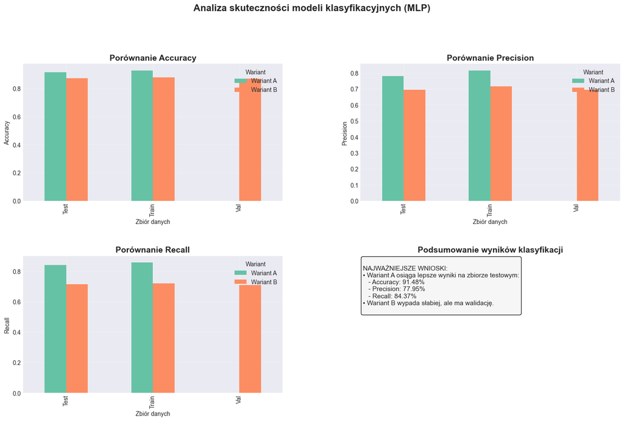

```python
with open('results/classification_results_A.json') as f:
    results_A = json.load(f)
with open('results/classification_results_B.json') as f:
    results_B = json.load(f)


# Ekstrakcja metryk
def extract_classification_metrics(result_dict, model_name):
    rows = []
    for split in ['train', 'val', 'test']:
        if split in result_dict['basic_model']:
            metrics = result_dict['basic_model'][split]
            row = {
                'Model': model_name,
                'Split': split.capitalize(),
                'Accuracy': metrics.get('accuracy_mean'),
                'Precision': metrics.get('precision_mean'),
                'Recall': metrics.get('recall_mean')
                # Dodaj F1 jak masz w danych: 'F1-score': metrics.get('f1_mean')
            }
            rows.append(row)
    return rows

df_metrics = pd.DataFrame(
    extract_classification_metrics(results_A, 'Wariant A') +
    extract_classification_metrics(results_B, 'Wariant B')
)

# Styl i paleta
plt.style.use('seaborn-v0_8-darkgrid')
sns.set_palette("Set2")

# Siatka wykresów
fig = plt.figure(figsize=(18, 10))
gs = GridSpec(2, 2, figure=fig, hspace=0.4, wspace=0.3)

# Accuracy
ax1 = fig.add_subplot(gs[0, 0])
df_metrics.pivot(index='Split', columns='Model', values='Accuracy').plot(kind='bar', ax=ax1)
ax1.set_title('Porównanie Accuracy', fontsize=14, fontweight='bold')
ax1.set_xlabel('Zbiór danych')
ax1.set_ylabel('Accuracy')
ax1.legend(title='Wariant')
ax1.grid(True, alpha=0.3)

# Precision
ax2 = fig.add_subplot(gs[0, 1])
df_metrics.pivot(index='Split', columns='Model', values='Precision').plot(kind='bar', ax=ax2)
ax2.set_title('Porównanie Precision', fontsize=14, fontweight='bold')
ax2.set_xlabel('Zbiór danych')
ax2.set_ylabel('Precision')
ax2.legend(title='Wariant')
ax2.grid(True, alpha=0.3)

# Recall
ax3 = fig.add_subplot(gs[1, 0])
df_metrics.pivot(index='Split', columns='Model', values='Recall').plot(kind='bar', ax=ax3)
ax3.set_title('Porównanie Recall', fontsize=14, fontweight='bold')
ax3.set_xlabel('Zbiór danych')
ax3.set_ylabel('Recall')
ax3.legend(title='Wariant')
ax3.grid(True, alpha=0.3)

# Podsumowanie
ax4 = fig.add_subplot(gs[1, 1])
summary_text = f"""
NAJWAŻNIEJSZE WNIOSKI:
• Wariant A osiąga lepsze wyniki na zbiorze testowym:
   - Accuracy: {results_A['basic_model']['test']['accuracy_mean']:.2%}
   - Precision: {results_A['basic_model']['test']['precision_mean']:.2%}
   - Recall: {results_A['basic_model']['test']['recall_mean']:.2%}
• Wariant B wypada słabiej, ale ma walidację.
"""
ax4.text(0.01, 0.98, summary_text, transform=ax4.transAxes,
         fontsize=11, verticalalignment='top',
         bbox=dict(boxstyle='round', facecolor='whitesmoke', alpha=0.9))
ax4.axis('off')
ax4.set_title('Podsumowanie wyników klasyfikacji', fontsize=14, fontweight='bold')

# Tytuł całości
plt.suptitle("Analiza skuteczności modeli klasyfikacyjnych (MLP)", fontsize=16, fontweight='bold', y=1.02)
plt.tight_layout()
plt.show()
```

**Analiza skuteczności modeli klasyfikacyjnych (MLP)** **Wyniki dla wariantu A (80/20)**

Model w wariancie A uzyskał najlepsze rezultaty na zbiorze testowym:

Accuracy: 91,48%

Precision: 77,95%

Recall: 84,37%

F1-score: 81,01%

Model charakteryzuje się wysoką skutecznością oraz dobrym zrównoważeniem między precision a recall, co oznacza, że potrafi zarówno poprawnie identyfikować zaakceptowane roszczenia, jak i utrzymywać umiarkowany poziom błędów fałszywych alarmów. Brak wyraźnej różnicy między wynikami ze zbioru treningowego i testowego wskazuje na brak przeuczenia.

**Wyniki dla wariantu B (70/15/15)**

Wariant B, z dodatkowym podziałem na zbiór walidacyjny, uzyskał nieco słabsze wyniki liczbowe (niższe accuracy, precision i recall). Jest to efekt mniejszej ilości danych treningowych oraz dodatkowej kontroli procesu uczenia za pomocą walidacji.

Choć wyniki numeryczne są niższe, wariant B umożliwia dokładniejsze monitorowanie generalizacji, co pozwala skuteczniej zapobiegać przeuczeniu i stabilizować proces uczenia.

**Wnioski:**

-Sieć neuronowa skutecznie identyfikuje wzorce związane z akceptacją roszczeń ubezpieczeniowych i osiąga wysoką skuteczność klasyfikacji.

-Wariant A zapewnił najlepsze wyniki predykcyjne, co czyni go najbardziej efektywną konfiguracją przy tym zbiorze danych.

-Wariant B zapewnia większą kontrolę nad procesem trenowania i jest korzystniejszy w sytuacjach wymagających oceny generalizacji, choć kosztem nieco słabszych wyników testowych.

Wariant A - 80/20

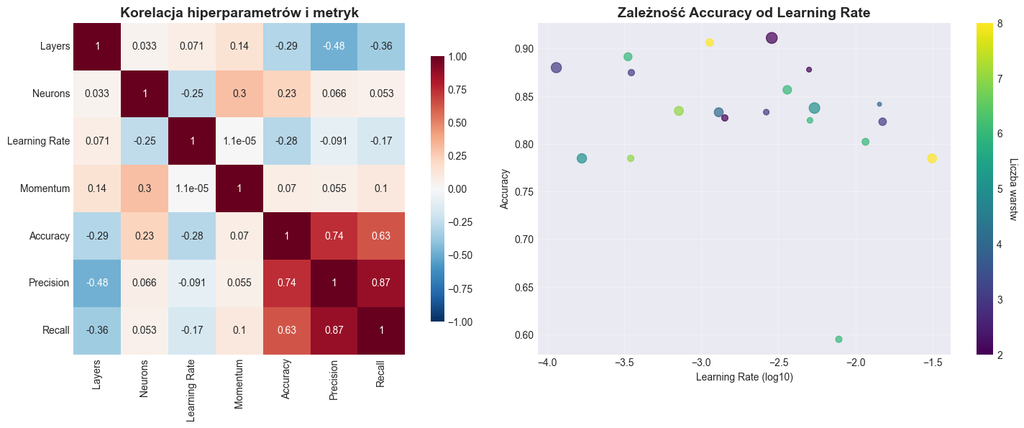

```python
# Przygotuj dane do analizy — wyciągamy sensowne modele z random search
def prepare_classification_corr_data(results):
    models = []
    for idx in results['random_search']['accuracy_mean']:
        acc = results['random_search']['accuracy_mean'][idx]
        if acc > 0.5:  # filtrowanie bardzo złych modeli
            models.append({
                'Layers': results['random_search']['n_hidden_layers'][idx],
                'Neurons': results['random_search']['n_neurons'][idx],
                'Learning Rate': np.log10(results['random_search']['learning_rate'][idx]),
                'Momentum': results['random_search']['momentum'][idx],
                'Accuracy': acc,
                'Precision': results['random_search']['precision_mean'][idx],
                'Recall': results['random_search']['recall_mean'][idx]
                # Dodaj F1-score jeśli masz: 'F1': results['random_search']['f1_mean'][idx]
            })
    return pd.DataFrame(models)

# Przygotuj dane
df_corr = prepare_classification_corr_data(results_A)

# Wykresy: Heatmapa + Scatter
fig, axes = plt.subplots(1, 2, figsize=(16, 6))

# Korelacja
corr_matrix = df_corr.corr()
sns.heatmap(corr_matrix, annot=True, cmap='RdBu_r', center=0,
            square=True, ax=axes[0], vmin=-1, vmax=1,
            cbar_kws={"shrink": 0.8})
axes[0].set_title('Korelacja hiperparametrów i metryk', fontsize=14, fontweight='bold')

# Scatter: Learning Rate vs Accuracy
axes[1].scatter(df_corr['Learning Rate'], df_corr['Accuracy'],
                c=df_corr['Layers'], s=df_corr['Neurons']/2,
                alpha=0.7, cmap='viridis')
axes[1].set_xlabel('Learning Rate (log10)')
axes[1].set_ylabel('Accuracy')
axes[1].set_title('Zależność Accuracy od Learning Rate', fontsize=14, fontweight='bold')
axes[1].grid(True, alpha=0.3)

# Colorbar (warstwy)
sm = plt.cm.ScalarMappable(cmap='viridis', norm=plt.Normalize(vmin=df_corr['Layers'].min(), vmax=df_corr['Layers'].max()))
sm.set_array([])
cbar = plt.colorbar(sm, ax=axes[1])
cbar.set_label('Liczba warstw', rotation=270, labelpad=15)

plt.tight_layout()
plt.show()
```

**Macierz korelacji**

pozwala zrozumieć, które hiperparametry mają realny wpływ na skuteczność modelu.

-Zwiększanie liczby warstw pogarsza skuteczność modelu. Model staje się zbyt złożony jak na charakter danych, co prowadzi do gorszej generalizacji. Najbardziej cierpi Precision, co oznacza większą liczbę fałszywych alarmów przy głębszych sieciach.

-Learning rate wykazuje umiarkowaną ujemną korelację z metrykami jakości. Oznacza to, że w badanym zakresie wyższe wartości współczynnika uczenia miały tendencję do obniżania skuteczności modelu. Jest to wpływ zauważalny, choć nie dominujący.

-Wpływ liczby neuronów jest słaby lub bardzo słaby.Lekko dodatnia korelacja z Accuracy (0.23) wskazuje, że umiarkowane zwiększanie liczby neuronów może minimalnie poprawić dokładność, ale efekt jest ograniczony.

-Momentum ma bardzo słaby, praktycznie pomijalny wpływ na jakość modelu. Wszystkie wartości korelacji są blisko zera, co oznacza, że w badanym zakresie momentum nie zmieniało ani skuteczności klasyfikacji, ani stabilności uczenia w istotny sposób.

**Zależność dokładności modelu (Accuracy) od współczynnika uczenia (Learning Rate)**

Najwyższe wartości Accuracy (≈0.88–0.91) pojawiają się przy niskich learning rate, co potwierdza, że wolniejsza, bardziej stabilna optymalizacja sprzyja lepszej generalizacji modelu.

Dla wyższych wartości learning rate obserwujemy spadek dokładności - sieć aktualizuje wagi zbyt agresywnie i traci stabilność uczenia.

Wariant B - 70/15/15

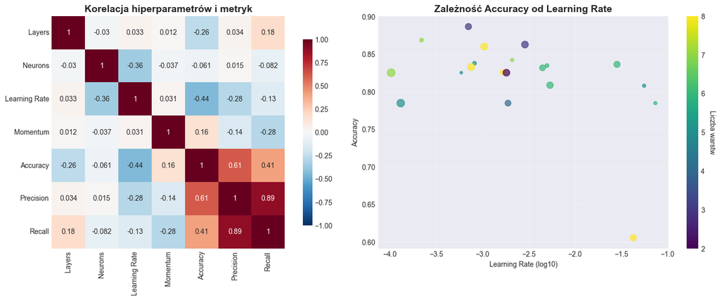

```python
# Przygotuj dane do analizy — wyciągamy sensowne modele z random search
def prepare_classification_corr_data(results):
    models = []
    for idx in results['random_search']['accuracy_mean']:
        acc = results['random_search']['accuracy_mean'][idx]
        if acc > 0.5:  # filtrowanie bardzo złych modeli
            models.append({
                'Layers': results['random_search']['n_hidden_layers'][idx],
                'Neurons': results['random_search']['n_neurons'][idx],
                'Learning Rate': np.log10(results['random_search']['learning_rate'][idx]),
                'Momentum': results['random_search']['momentum'][idx],
                'Accuracy': acc,
                'Precision': results['random_search']['precision_mean'][idx],
                'Recall': results['random_search']['recall_mean'][idx]
                # Dodaj F1-score jeśli masz: 'F1': results['random_search']['f1_mean'][idx]
            })
    return pd.DataFrame(models)

# Przygotuj dane
df_corr = prepare_classification_corr_data(results_B)

# Wykresy: Heatmapa + Scatter
fig, axes = plt.subplots(1, 2, figsize=(16, 6))

# Korelacja
corr_matrix = df_corr.corr()
sns.heatmap(corr_matrix, annot=True, cmap='RdBu_r', center=0,
            square=True, ax=axes[0], vmin=-1, vmax=1,
            cbar_kws={"shrink": 0.8})
axes[0].set_title('Korelacja hiperparametrów i metryk', fontsize=14, fontweight='bold')

# Scatter: Learning Rate vs Accuracy
axes[1].scatter(df_corr['Learning Rate'], df_corr['Accuracy'],
                c=df_corr['Layers'], s=df_corr['Neurons']/2,
                alpha=0.7, cmap='viridis')
axes[1].set_xlabel('Learning Rate (log10)')
axes[1].set_ylabel('Accuracy')
axes[1].set_title('Zależność Accuracy od Learning Rate', fontsize=14, fontweight='bold')
axes[1].grid(True, alpha=0.3)

# Colorbar (warstwy)
sm = plt.cm.ScalarMappable(cmap='viridis', norm=plt.Normalize(vmin=df_corr['Layers'].min(), vmax=df_corr['Layers'].max()))
sm.set_array([])
cbar = plt.colorbar(sm, ax=axes[1])
cbar.set_label('Liczba warstw', rotation=270, labelpad=15)

plt.tight_layout()
plt.show()
```

**Macierz korelacji**

-Liczba warstw wykazuje słabą i niespójną zależność z metrykami jakości. Umiarkowanie ujemna korelacja z Accuracy (–0.26) sugeruje, że głębsze sieci mogą minimalnie pogarszać dokładność. Oznacza to, że rozbudowa architektury nie miała wyraźnego wpływu na jakość klasyfikacji.

-Learning rate wykazuje najsilniejszą ujemną korelację spośród wszystkich hiperparametrów (–0.44 dla Accuracy). Oznacza to, że wyższe wartości współczynnika uczenia obniżały skuteczność modelu, a stabilne, niskie wartości learning rate były kluczowe dla poprawnej generalizacji. Jest to jedyny parametr mający wyraźny, konsekwentny wpływ na jakość.

-Liczba neuronów ma bardzo słaby wpływ na wyniki modelu (korelacje bliskie zeru).

-Momentum wykazuje słabe korelacje z metrykami jakości. W praktyce oznacza to, że zmiana tego parametru miała niewielki wpływ na stabilność i skuteczność uczenia, a model był w dużej mierze na momentum odporny.

**Zależność dokładności modelu (Accuracy) od współczynnika uczenia (Learning Rate)**

-Najwyższe wartości Accuracy (≈0.85–0.89) występują przy nizszych/średnich wartościach learning rate (log10 ≈ –4.0 do –2.5).

-Wraz ze wzrostem współczynnika uczenia (log10 bliżej –2.0 i wyżej) jakość modelu spada.

-Kolor punktów odzwierciedla liczbę warstw, jednak rozmieszczenie kolorów ponownie nie tworzy wyraźnego trendu.

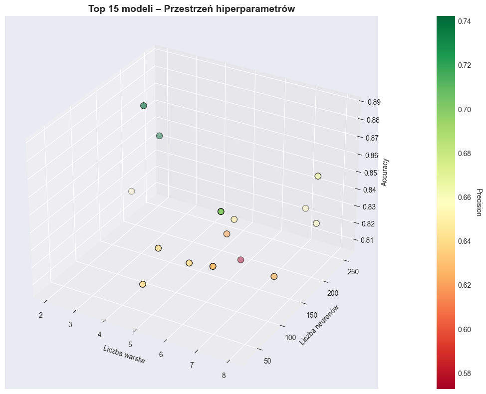

```python
# 3D scatter plot – Top 15 modeli z najwyższym Accuracy
fig3 = plt.figure(figsize=(12, 8))
ax3d = fig3.add_subplot(111, projection='3d')

top_models = df_corr.nlargest(15, 'Accuracy')

scatter = ax3d.scatter(
    top_models['Layers'],
    top_models['Neurons'],
    top_models['Accuracy'],
    c=top_models['Precision'],  # kolor wg Precision
    cmap='RdYlGn',
    s=80,
    edgecolor='black'
)

ax3d.set_xlabel('Liczba warstw')
ax3d.set_ylabel('Liczba neuronów')
ax3d.set_zlabel('Accuracy')
ax3d.set_title('Top 15 modeli – Przestrzeń hiperparametrów', fontsize=14, fontweight='bold')

cbar = plt.colorbar(scatter, ax=ax3d, pad=0.1)
cbar.set_label('Precision', rotation=270, labelpad=15)

plt.tight_layout()
plt.show()
```

-Liczba neuronów nie wykazuje wyraźnego trendu.

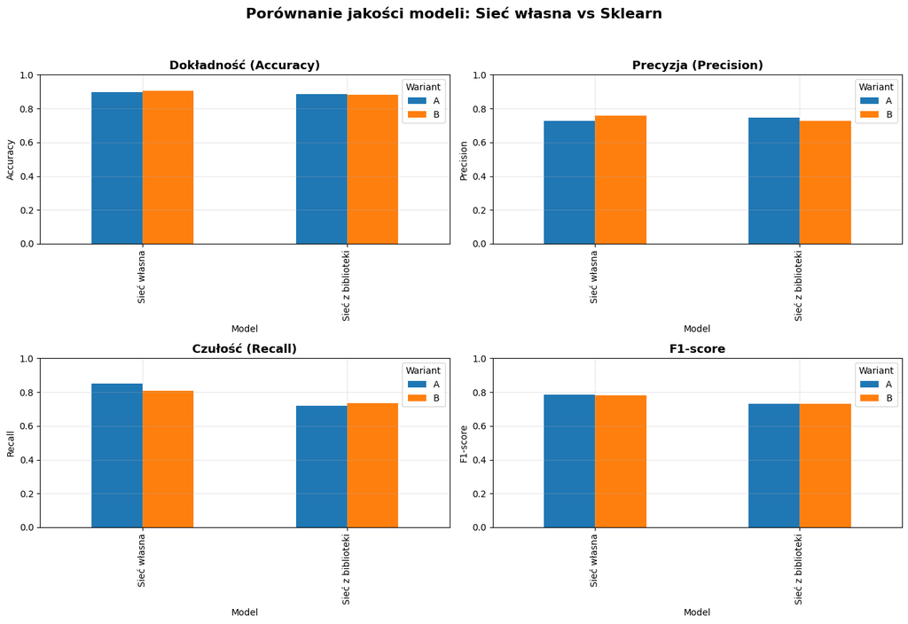

```python
# Wariant A – własna sieć vs sklearn
a_compare = pd.DataFrame([
    {'Wariant': 'A', 'Model': 'Sieć własna', 'Accuracy': 0.898643, 'Precision': 0.726554, 'Recall': 0.848716, 'F1-score': 0.782898, 'Train Time': 79.72},
    {'Wariant': 'A', 'Model': 'Sieć z biblioteki', 'Accuracy': 0.886460, 'Precision': 0.744398, 'Recall': 0.719904, 'F1-score': 0.731946, 'Train Time': 32.41}
])

# Wariant B – własna sieć vs sklearn
b_compare = pd.DataFrame([
    {'Wariant': 'B', 'Model': 'Sieć własna', 'Accuracy': 0.902880, 'Precision': 0.757789, 'Recall': 0.806849, 'F1-score': 0.781550, 'Train Time': 41.59},
    {'Wariant': 'B', 'Model': 'Sieć z biblioteki', 'Accuracy': 0.883065, 'Precision': 0.725926, 'Recall': 0.734082, 'F1-score': 0.729981, 'Train Time': 18.31}
])

# Połącz dane
full_compare = pd.concat([a_compare, b_compare], ignore_index=True)

# === Wykres porównawczy ===
fig, axes = plt.subplots(2, 2, figsize=(14, 10))
metrics = ['Accuracy', 'Precision', 'Recall', 'F1-score']
titles = ['Dokładność (Accuracy)', 'Precyzja (Precision)', 'Czułość (Recall)', 'F1-score']

for i, metric in enumerate(metrics):
    ax = axes[i//2, i%2]
    full_compare.pivot(index='Model', columns='Wariant', values=metric).plot(kind='bar', ax=ax)
    ax.set_title(titles[i], fontsize=13, fontweight='bold')
    ax.set_ylabel(metric)
    ax.set_ylim(0, 1)
    ax.grid(True, alpha=0.3)
    ax.legend(title='Wariant')

plt.suptitle('Porównanie jakości modeli: Sieć własna vs Sklearn', fontsize=16, fontweight='bold')
plt.tight_layout(rect=[0, 0.03, 1, 0.95])
plt.show()
```

-Dla obu wariantów odnotowano dokładność na poziomie około 0.9, co oznacza, że modele prawidłowo przewidziały decyzję o akceptacji roszczenia dla około 90% przypadków.

-Pod względem czułości (Recall), sieć własna uzyskała wyższy wynik (ok. 0.83) w porównaniu do modelu z biblioteki, co sugeruje, że lepiej rozpoznaje przypadki zaakceptowanych roszczeń (klasa pozytywna).

-Precyzja i F1-score pozostają na zbliżonym poziomie w obu podejściach, co wskazuje na równowagę między trafnością i kompletnością klasyfikacji.

Porównanie wariantów A i B nie wykazało znaczących różnic w jakości predykcji — co oznacza, że dodatkowy podział na zbiór walidacyjny (wariant B) nie wpłynął istotnie na ogólną skuteczność modeli.

```python
#Top konfiguracje z random search
top_configs_A = pd.DataFrame([
    {'Layers': 2, 'Neurons': 240, 'Learning Rate': 0.002864, 'Opt': 'RMSProp', 'Act': 'tanh', 'Accuracy': 0.911000},
    {'Layers': 8, 'Neurons': 112, 'Learning Rate': 0.001133, 'Opt': 'Adam', 'Act': 'relu', 'Accuracy': 0.906218},
    {'Layers': 6, 'Neurons': 128, 'Learning Rate': 0.000335, 'Opt': 'RMSProp', 'Act': 'elu', 'Accuracy': 0.891270}
])

top_configs_B = pd.DataFrame([
    {'Layers': 3, 'Neurons': 160, 'Learning Rate': 0.000704, 'Opt': 'RMSProp', 'Act': 'leaky_relu', 'Accuracy': 0.886412},
    {'Layers': 7, 'Neurons': 64, 'Learning Rate': 0.000219, 'Opt': 'RMSProp', 'Act': 'tanh', 'Accuracy': 0.868392},
    {'Layers': 3, 'Neurons': 192, 'Learning Rate': 0.002875, 'Opt': 'RMSProp', 'Act': 'leaky_relu', 'Accuracy': 0.862539}
])

print(" Top 3 konfiguracje – Wariant A(80/20):")
display(top_configs_A)

print("\n Top 3 konfiguracje – Wariant B(70/15/15):")
display(top_configs_B)
```

```
 Top 3 konfiguracje – Wariant A(80/20):
```

|  | Layers | Neurons | Learning Rate | Opt | Act | Accuracy |
| --- | --- | --- | --- | --- | --- | --- |
| 0 | 2 | 240 | 0.002864 | RMSProp | tanh | 0.911000 |
| 1 | 8 | 112 | 0.001133 | Adam | relu | 0.906218 |
| 2 | 6 | 128 | 0.000335 | RMSProp | elu | 0.891270 |

```
 Top 3 konfiguracje – Wariant B(70/15/15):
```

|  | Layers | Neurons | Learning Rate | Opt | Act | Accuracy |
| --- | --- | --- | --- | --- | --- | --- |
| 0 | 3 | 160 | 0.000704 | RMSProp | leaky_relu | 0.886412 |
| 1 | 7 | 64 | 0.000219 | RMSProp | tanh | 0.868392 |
| 2 | 3 | 192 | 0.002875 | RMSProp | leaky_relu | 0.862539 |